# 542 Deliverable 2

Daghan Yildiz

2/14/2022

# First, I’ll bring the dataset that I prepared on Python during the first section of the course from my GitHub (It’s a RDS file):

```r
link='https://github.com/dghnyldz/computational-thinking/raw/main/FinalData.RDS'
# a RDS file from the web needs:
myFile=url(link)
# reading in data:
fromPy=readRDS(file = myFile)
# reset indexes to R format:
row.names(fromPy)=NULL
# check data types
str(fromPy)
```

```
## 'data.frame':    205 obs. of  13 variables:
##  $ Country           : chr  "China" "United States" "India" "Japan" ...
##  $ TotalGDPinMillions: int  23210000 19490000 9474000 5443000 4199000 4016000 3250000 3248000 2925000 2856000 ...
##  $ AgriPercent       : num  7.9 0.9 15.4 1.1 0.7 4.7 13.7 6.6 0.7 1.7 ...
##  $ InduPercent       : num  40.5 19.1 23 30.1 30.7 32.4 41 20.7 20.2 19.5 ...
##  $ ServPercent       : num  51.6 80 61.5 68.7 68.6 62.3 45.4 72.7 79.2 78.8 ...
##  $ AgriDollar        : int  1833590 175410 1458996 59873 29393 188752 445250 214368 20475 48552 ...
##  $ InduDollar        : int  9400050 3722590 2179020 1638343 1289093 1301184 1332500 672336 590850 556920 ...
##  $ ServDollar        : int  11976360 15592000 5826510 3739341 2880514 2501968 1475500 2361296 2316600 2250528 ...
##  $ InternetccTLD     : chr  ".cn" ".us" ".in" ".jp" ...
##  $ ISO2              : chr  "CN" "US" "IN" "JP" ...
##  $ ISO3              : chr  "CHN" "USA" "IND" "JPN" ...
##  $ CO2x1000          : int  2806634 1432855 610411 331074 196314 465052 126582 144480 114486 82704 ...
##  $ Population        : num  1444216 332915 1393409 126051 83900 ...
```

**Now I want to select the variables I want to use for clustering, so I am subsetting the data. I want to cluster based on the percentages of each economic sector (agriculture, industry, and service):**

```r
selection=c("Country","AgriPercent", "InduPercent","ServPercent")
dataToCluster=fromPy[,selection]

#I will set the country names as row names:

row.names(dataToCluster)=dataToCluster$Country
dataToCluster$Country=NULL
```

**Now I will see if I need to transform (standardize) the data by looking at the box plot:**

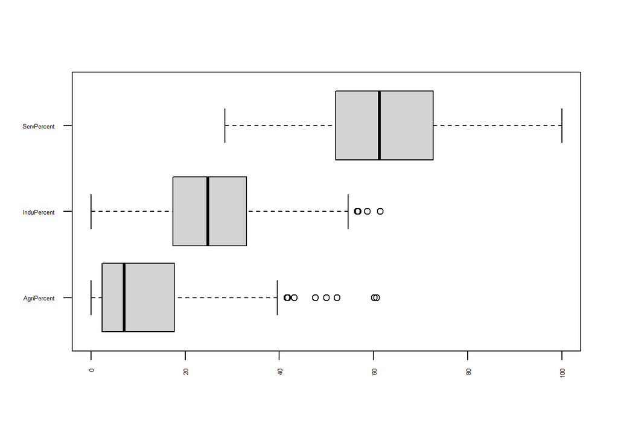

```r
boxplot(dataToCluster,horizontal = T, las=2,cex.axis=0.4)
```

**Ranges are not very different, but not very similar either. So I will transform them:**

```r
as.data.frame(scale(dataToCluster))
```

[output not shown]

[output cut: 151 more lines]

```
## Turks and Caicos Islands          -0.906544647 -1.42807732  1.947944052
## Tonga                              0.687322754 -0.47105708 -0.186613175
## Saint Martin                      -0.865465590 -0.91598754  1.490538931
## British Virgin Islands            -0.931192081 -1.60437052  2.121203567
## Micronesia, Federated States of    1.213134680 -0.58858588 -0.533132206
## Cook Islands                      -0.528617325 -1.10907057  1.358861700
## Palau                             -0.701149364 -0.58019096  1.074716095
## Saint Pierre and Miquelon         -0.783307477 -0.91598754  1.421235125
## Kiribati                           0.942012906 -1.58758069  0.520285647
## Marshall Islands                  -0.586128005 -1.34412817  1.608355402
## Anguilla                          -0.701149364 -1.29375869  1.656868066
## Montserrat                        -0.791523288 -1.52042138  1.927152910
## Nauru                             -0.446459212  0.59509705 -0.117309369
## Tuvalu                             1.065250076 -1.70510949  0.520285647
## Niue                               0.983091963  0.08300728 -0.900442378
```

**Saving it:**

```r
Scaled <- scale(dataToCluster)
```

**Now they all have similar range:**

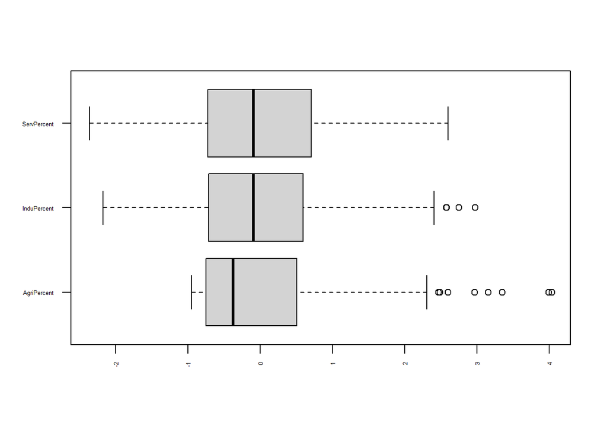

```r
boxplot(Scaled,horizontal = T, las=2,cex.axis=0.4)
```

**Setting random seed and computing distance matrix:**

```r
set.seed(999)

library(cluster)
Scaled_DM=daisy(x=Scaled, metric = "gower")
```

**Using function fviz_nbclust to see the optimal number of clusters:**

```r
library(factoextra)
```

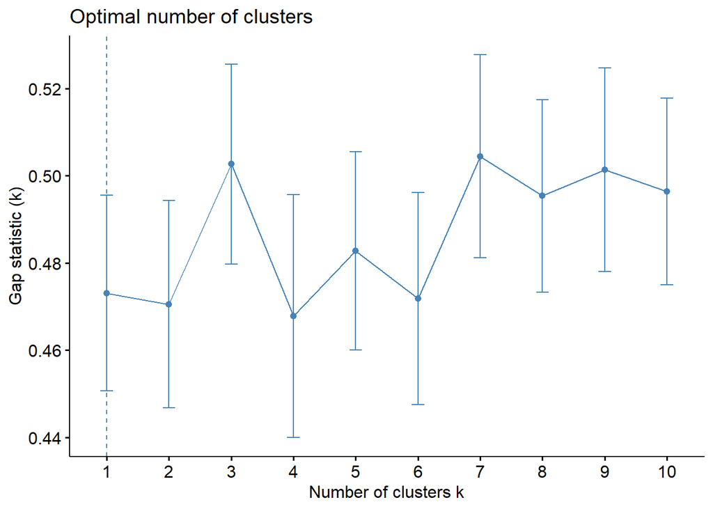

```r
fviz_nbclust(Scaled,
             pam,
             diss=Scaled_DM,
             method = "gap_stat",
             k.max = 10,verbose = F)
```

**For hierarchical (agglomerative):**

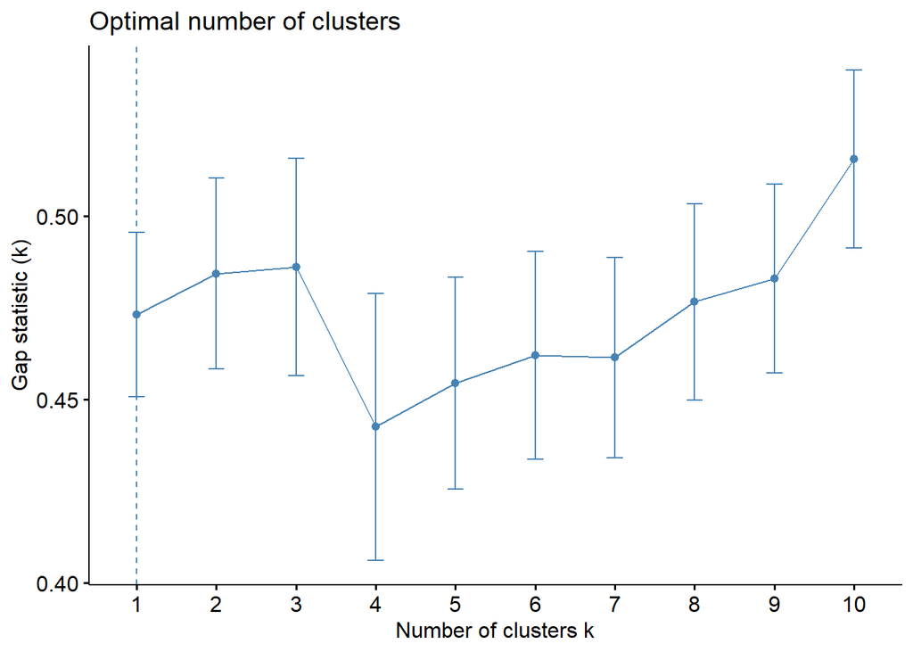

```r
fviz_nbclust(Scaled,
             hcut,
             diss=Scaled_DM,
             method = "gap_stat",
             k.max = 10,
             verbose = F,
             hc_func = "agnes")
```

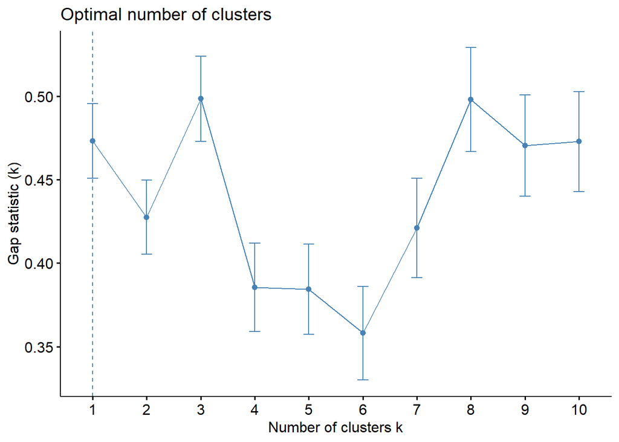

```r
fviz_nbclust(Scaled,
             hcut,
             diss=Scaled_DM,
             method = "gap_stat",
             k.max = 10,
             verbose = F,
             hc_func = "diana")
```

**They all show 1 as the optimal number, however I will go ahead and set 4 clusters:**

```r
NumberOfClusters=4

#Partitioning (pam):
res.pam = pam(x=Scaled_DM,
              k = NumberOfClusters,
              cluster.only = F)

#Hierarchical - agglomerative (agnes):

res.agnes= hcut(Scaled_DM,
                k = NumberOfClusters,
                isdiss=TRUE,
                hc_func='agnes',
                hc_method = "ward.D2")

#Hierarchical - divisive (diana):
res.diana= hcut(Scaled_DM,
                k = NumberOfClusters,
                isdiss=TRUE,
                hc_func='diana',
                hc_method = "ward.D2")
```

**Now I will add the results to the dataframe (fromPy). This will add new variables to the original dataframe that will tell me which country is in which cluster:**

```r
fromPy$pam=as.factor(res.pam$clustering)
fromPy$agn=as.factor(res.agnes$cluster)
fromPy$dia=as.factor(res.diana$cluster)
```

**Now, I will plot the silhouettes, starting with pam:**

```
##   cluster size ave.sil.width
## 1       1   44          0.32
## 2       2   44          0.46
## 3       3   51          0.28
## 4       4   66          0.44
```

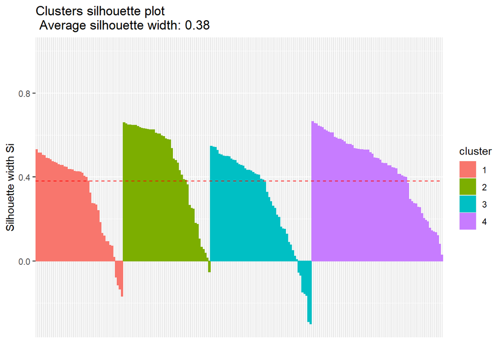

```r
fviz_silhouette(res.pam)
```

**Agnes:**

```
##   cluster size ave.sil.width
## 1       1   74          0.32
## 2       2   52          0.60
## 3       3   70          0.19
## 4       4    9          0.65
```

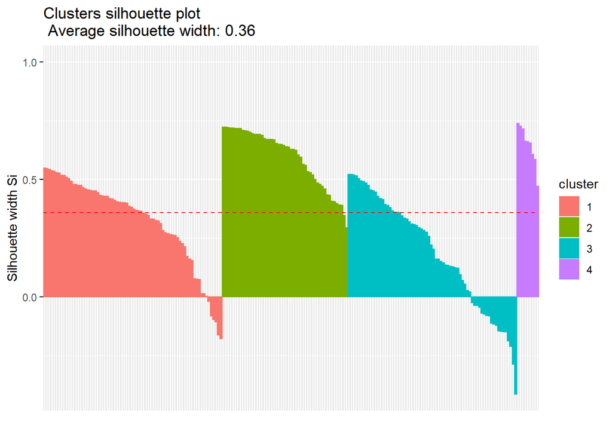

```r
fviz_silhouette(res.agnes)
```

**Diana:**

```
##   cluster size ave.sil.width
## 1       1   68          0.37
## 2       2   69          0.49
## 3       3   54          0.22
## 4       4   14          0.44
```

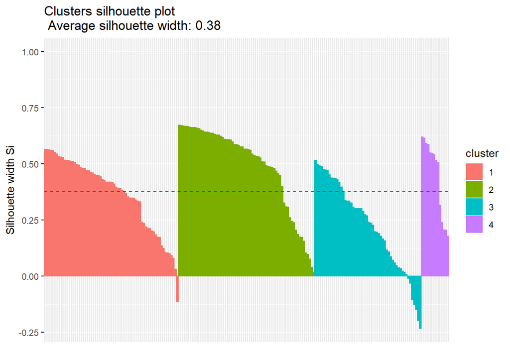

```r
fviz_silhouette(res.diana)
```

**Pam (partitioning) and Diana (hierarchical - divisive) do a better job than Agnes (hierarchical - agglomerative) as their average silhouette width is higher (0.38 vs. 0.36).**

**So, the best way to cluster is either partitioning or hierarhical - divisive. Let’s take a look at the badly clustered cases:**

```r
head(data.frame(res.pam$silinfo$widths),10)
```

```
##              cluster neighbor sil_width
## Turkmenistan       1        4 0.5298294
## Eswatini           1        4 0.5148031
## Indonesia          1        4 0.5140548
## Bhutan             1        4 0.5040376
## Serbia             1        4 0.5019458
## Iraq               1        4 0.4886707
## Azerbaijan         1        4 0.4876771
## Algeria            1        4 0.4815309
## Gabon              1        4 0.4738781
## Libya              1        4 0.4697944
```

**It is important to note that there is no ordinality between the clusters.**

**Saving the nagative silhouette values:**

```r
pamEval=data.frame(res.pam$silinfo$widths)
agnEval=data.frame(res.agnes$silinfo$widths)
diaEval=data.frame(res.diana$silinfo$widths)

pamPoor=rownames(pamEval[pamEval$sil_width<0,])
agnPoor=rownames(agnEval[agnEval$sil_width<0,])
diaPoor=rownames(diaEval[diaEval$sil_width<0,])
```

```r
library("qpcR")
```

**Now we can see the number of badly clustered cases in each method:**

```r
bap_Clus=as.data.frame(qpcR:::cbind.na(sort(pamPoor), sort(agnPoor),sort(diaPoor)))
names(bap_Clus)=c("pam","agn","dia")
bap_Clus
```

```
##           pam                   agn       dia
## 1     Armenia               Algeria   Algeria
## 2     Bahrain               Andorra    Angola
## 3    Cameroon             Argentina   Bolivia
## 4      Guyana             Australia Guatemala
## 5       India                Belize Indonesia
## 6     Ireland               Bolivia  Kiribati
## 7  Kyrgyzstan               Croatia  Mongolia
## 8     Moldova                 Egypt    Tuvalu
## 9   Nicaragua           El Salvador      <NA>
## 10   Paraguay               Eritrea      <NA>
## 11    Senegal              Ethiopia      <NA>
## 12     Zambia                  Fiji      <NA>
## 13       <NA>             Greenland      <NA>
## 14       <NA>                Guyana      <NA>
## 15       <NA>             Indonesia      <NA>
## 16       <NA>                 Kenya      <NA>
## 17       <NA>               Liberia      <NA>
## 18       <NA>              Mongolia      <NA>
## 19       <NA>         New Caledonia      <NA>
## 20       <NA> Sao Tome and Principe      <NA>
## 21       <NA>                 Sudan      <NA>
## 22       <NA>              Suriname      <NA>
## 23       <NA>               Ukraine      <NA>
## 24       <NA>               Uruguay      <NA>
## 25       <NA>              Zimbabwe      <NA>
```

**We see that, even though Pam and Diane have the same average silhouette width, Diana is a better way to cluster as it has less poorly clustered cases.**

**Let’s plot Diana:**

```r
projectedData = cmdscale(Scaled_DM, k=2)
```

```r
#
# save coordinates to original data frame:
fromPy$dim1 = projectedData[,1]
fromPy$dim2 = projectedData[,2]

# see some:

fromPy[,c('dim1','dim2')][1:10,]
```

```
##           dim1         dim2
## 1  -0.08594668  0.121360253
## 2   0.16161712 -0.007709638
## 3  -0.02177756 -0.037753440
## 4   0.07898065  0.082353728
## 5   0.07929294  0.088616840
## 6   0.01765109  0.082276549
## 7  -0.16692733  0.097808795
## 8   0.08837146 -0.015192226
## 9   0.15582664  0.001815650
## 10  0.15014395 -0.006291927
```

**Plotting the “map”:**

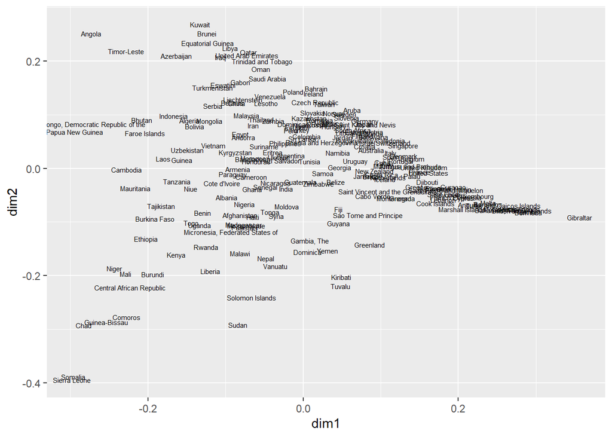

```r
base= ggplot(data=fromPy,
             aes(x=dim1, y=dim2,
                 label=Country))
base + geom_text(size=2)
```

**I will only show Diana, so I am coloring the map using the labels from Diana:**

```r
diaPlot=base + labs(title = "DIANA") + geom_point(size=2,
                                              aes(color=dia),
                                              show.legend = T)
```

```r
library(ggpubr)
```

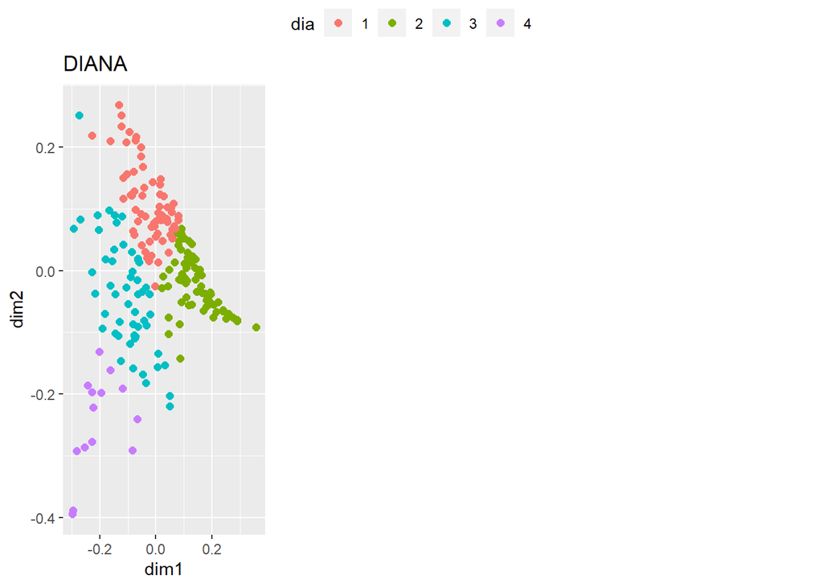

```r
ggarrange(diaPlot,ncol = 3,common.legend = T)
```

**Let’s annotate the outliers:**

```r
LABELdia=ifelse(fromPy$Country%in%diaPoor,fromPy$Country,"")
```

```r
library(ggrepel)
```

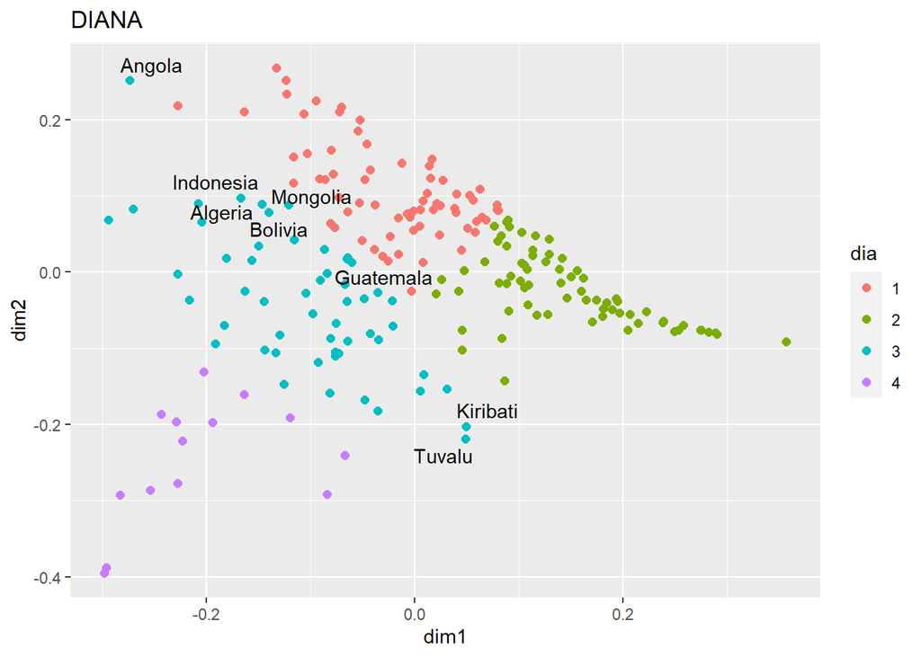

```r
diaPlot + geom_text_repel(aes(label=LABELdia))
```

**End of clustering analysis.**

# Now, factor analysis to explore whether there is a latent concept:

**I am subsetting the data one more time:**

```r
selection1=c("Country","AgriPercent","InduPercent","ServPercent")

dataForFA=fromPy[,selection1]
```

```r
library(lavaan)
model='
econo=~AgriPercent + InduPercent + ServPercent'

fit<-cfa(model, data = dataForFA,std.lv=TRUE)
indexCFA=lavPredict(fit)
indexCFA[1:10]
```

```
##  [1]  -6.150655 -48.270869  15.047073  -1.645174 -32.808604 164.357052
##  [7] -26.012184 -35.571322 -78.382937 -46.249044
```

```r
library(scales)
indexCFANorm=rescale(as.vector(indexCFA),
                     to = c(0, 10))
indexCFANorm[1:10]
```

```
##  [1] 0.7520825 0.6294247 0.8138121 0.7652028 0.6744522 1.2486160 0.6942440
##  [8] 0.6664069 0.5417357 0.6353124
```

```r
fromPy$GDP_FA=indexCFANorm
```

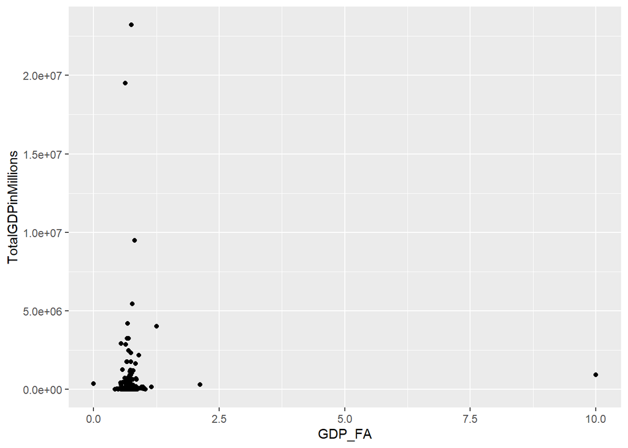

```r
base=ggplot(data=fromPy,
            aes(x=GDP_FA,y=TotalGDPinMillions))
base+geom_point()
```

**The dataset does not seem suitable for a factor analysis. At least, there does not seem to be a latent concept concerning the contributions of economic sectors to total GDP.**

# Regression:

**The dataset is already loaded, let’s verify it:**

```r
str(fromPy, width = 70,strict.width='cut')
```

```
## 'data.frame':    205 obs. of  19 variables:
##  $ Country           : chr  "China" "United States" "India" "Japan" ..
##  $ TotalGDPinMillions: int  23210000 19490000 9474000 5443000 419900..
##  $ AgriPercent       : num  7.9 0.9 15.4 1.1 0.7 4.7 13.7 6.6 0.7 1...
##  $ InduPercent       : num  40.5 19.1 23 30.1 30.7 32.4 41 20.7 20.2..
##  $ ServPercent       : num  51.6 80 61.5 68.7 68.6 62.3 45.4 72.7 79..
##  $ AgriDollar        : int  1833590 175410 1458996 59873 29393 18875..
##  $ InduDollar        : int  9400050 3722590 2179020 1638343 1289093 ..
##  $ ServDollar        : int  11976360 15592000 5826510 3739341 288051..
##  $ InternetccTLD     : chr  ".cn" ".us" ".in" ".jp" ...
##  $ ISO2              : chr  "CN" "US" "IN" "JP" ...
##  $ ISO3              : chr  "CHN" "USA" "IND" "JPN" ...
##  $ CO2x1000          : int  2806634 1432855 610411 331074 196314 465..
##  $ Population        : num  1444216 332915 1393409 126051 83900 ...
##  $ pam               : Factor w/ 4 levels "1","2","3","4": 1 2 3 4 4..
##  $ agn               : Factor w/ 4 levels "1","2","3","4": 1 2 3 1 1..
##  $ dia               : Factor w/ 4 levels "1","2","3","4": 1 2 3 1 1..
##  $ dim1              : num  -0.0859 0.1616 -0.0218 0.079 0.0793 ...
##  $ dim2              : num  0.12136 -0.00771 -0.03775 0.08235 0.0886..
##  $ GDP_FA            : num  0.752 0.629 0.814 0.765 0.674 ...
```

**I will be using the explanatory approach.**

**Hypothesis 1: CO2 emissions increase as the total GDP goes up.(Dependent variable: CO2x1000, independent variable: TotalGDPinMillions)**

```r
hypo1=formula(CO2x1000~ TotalGDPinMillions)
```

**Hypothesis 2: CO2 emissions increase as the total GDP and the population go up.***

```r
hypo2=formula(CO2x1000~ TotalGDPinMillions + Population)
```

**Computing regression models:**

```r
gauss1=glm(hypo1,
           data = fromPy,
           family = 'gaussian')

gauss2=glm(hypo2,
           data = fromPy,
           family = 'gaussian')
```

**Now let’s take a look at the results:**

**Hypothesis 1:**

```r
summary(gauss1)
```

```
##
## Call:
## glm(formula = hypo1, family = "gaussian", data = fromPy)
##
## Deviance Residuals:
##     Min       1Q   Median       3Q      Max
## -393403     2895    11345    13019   629302
##
## Coefficients:
##                      Estimate Std. Error t value Pr(>|t|)
## (Intercept)        -1.311e+04  4.781e+03  -2.742  0.00666 **
## TotalGDPinMillions  9.438e-02  2.011e-03  46.933  < 2e-16 ***
## ---
## Signif. codes:  0 '***' 0.001 '**' 0.01 '*' 0.05 '.' 0.1 ' ' 1
##
## (Dispersion parameter for gaussian family taken to be 4376857066)
##
##     Null deviance: 1.0529e+13  on 204  degrees of freedom
## Residual deviance: 8.8850e+11  on 203  degrees of freedom
## AIC: 5136.7
##
## Number of Fisher Scoring iterations: 2
```

**Hypothesis 2:**

```r
summary(gauss2)
```

```
##
## Call:
## glm(formula = hypo2, family = "gaussian", data = fromPy)
##
## Deviance Residuals:
##     Min       1Q   Median       3Q      Max
## -401968     1777    11740    13950   590954
##
## Coefficients:
##                      Estimate Std. Error t value Pr(>|t|)
## (Intercept)        -1.409e+04  4.719e+03  -2.986  0.00318 **
## TotalGDPinMillions  8.707e-02  3.309e-03  26.310  < 2e-16 ***
## Population          1.447e-01  5.251e-02   2.755  0.00640 **
## ---
## Signif. codes:  0 '***' 0.001 '**' 0.01 '*' 0.05 '.' 0.1 ' ' 1
##
## (Dispersion parameter for gaussian family taken to be 4239210769)
##
##     Null deviance: 1.0529e+13  on 204  degrees of freedom
## Residual deviance: 8.5632e+11  on 202  degrees of freedom
## AIC: 5131.1
##
## Number of Fisher Scoring iterations: 2
```

**Both hypotheses are true, as p-value for both of them shows statistical significance. Hypothesis 2 looks like a better model. Let’s confirm it:**

```r
anova(gauss1,gauss2,test="Chisq")
```

```
## Analysis of Deviance Table
##
## Model 1: CO2x1000 ~ TotalGDPinMillions
## Model 2: CO2x1000 ~ TotalGDPinMillions + Population
##   Resid. Df Resid. Dev Df   Deviance Pr(>Chi)
## 1       203 8.8850e+11
## 2       202 8.5632e+11  1 3.2181e+10 0.005865 **
## ---
## Signif. codes:  0 '***' 0.001 '**' 0.01 '*' 0.05 '.' 0.1 ' ' 1
```

**And the R-squared for the second model (hypothesis) is:**

```r
library(rsq)
rsq(gauss2,adj=T)
```

```
## [1] 0.9178687
```

**R-squared is 0.91, which means that 91% of the variation in our dependent variable (CO2 emissions) is explained by our model.**

**Let’s plot it:**

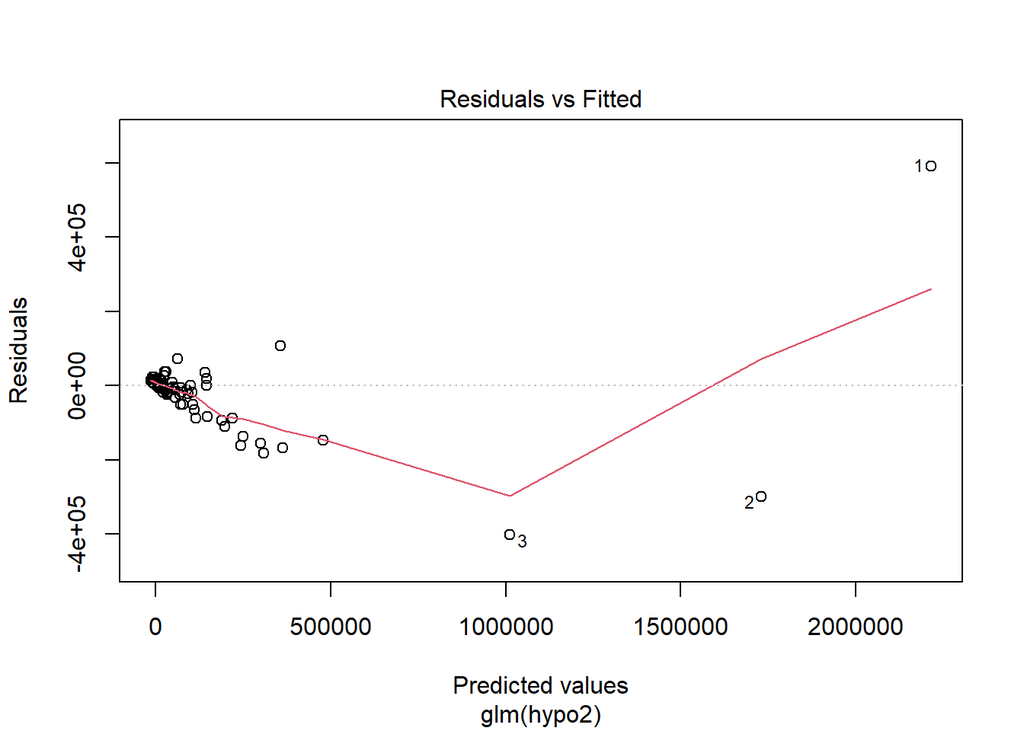

```r
plot(gauss2,1)
```

**Normality of residuals:**

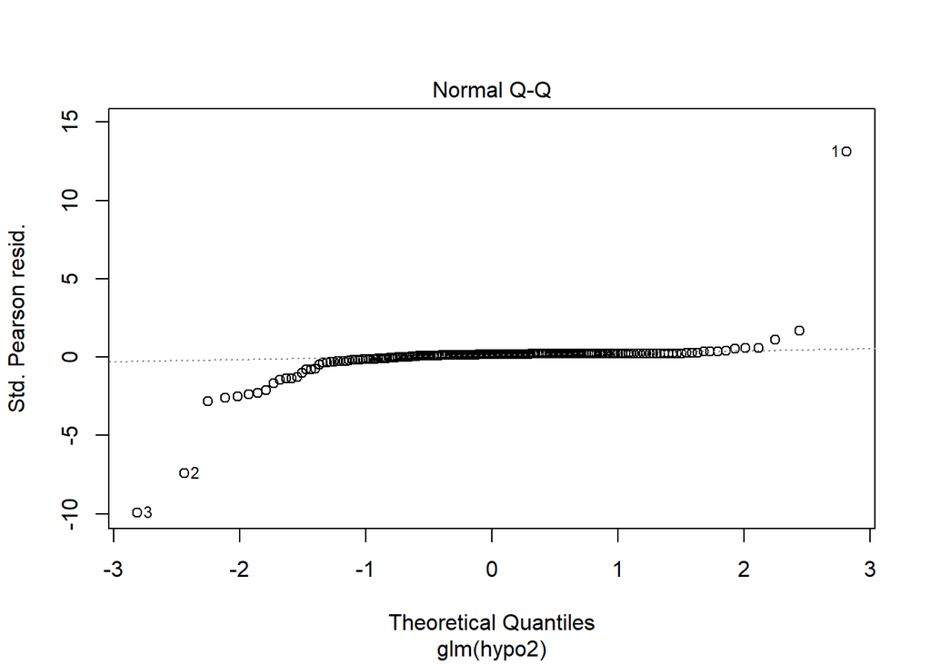

```r
plot(gauss2,2)
```

**Checking if residuals are equally spread along the ranges of predictors:**

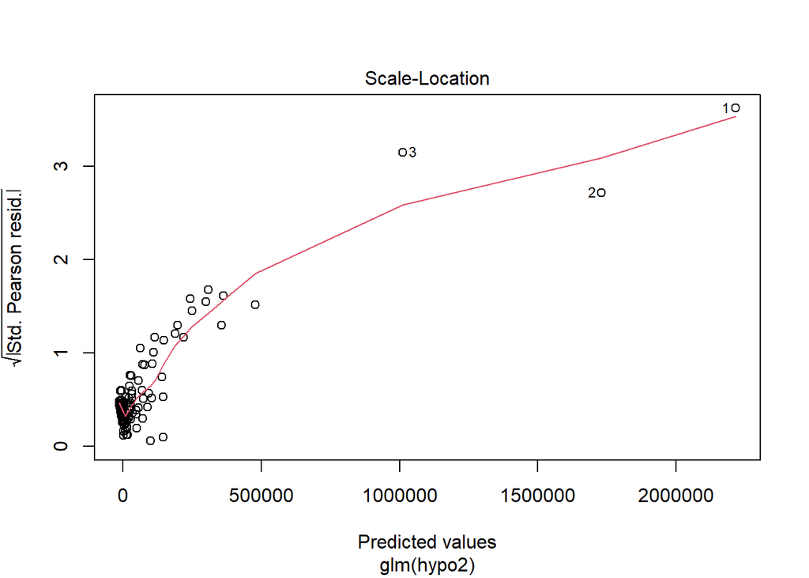

```r
plot(gauss2, 3)
```

**Summary plot of the regression analysis:**

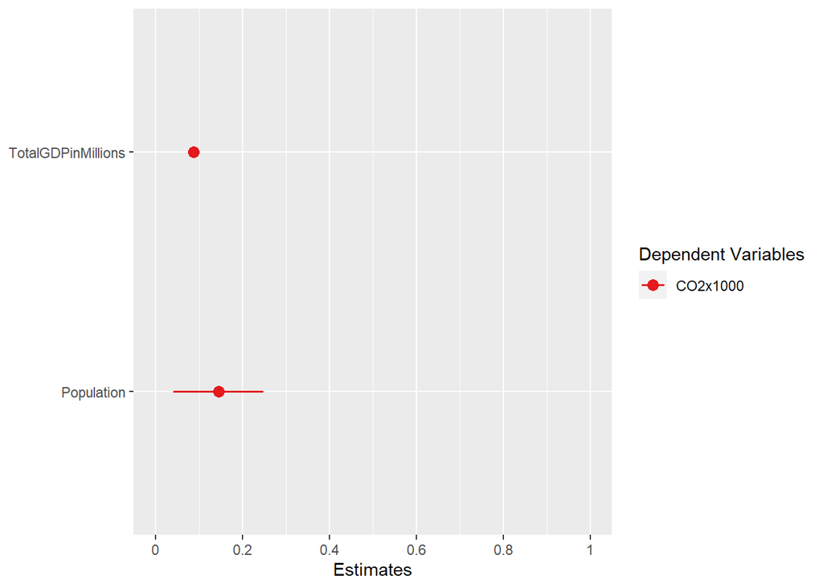

```r
library(sjPlot)
plot_models(gauss2,vline.color = "grey")
```